# Downstream methods

Many packages provide tools for downstream processing — e.g. plot diagnostics, model comparisons, visual plotting, and regression tables – that are compatible with `merMod` objects. This vignette provides instructions on some recommended packages with examples. Rather than attempting an exhaustive survey, We aimed to include the more popular packages.

## Diagnostic Plots

While `plot(merMod_object)` provides some diagnostic plots (see `?lme4::plot.merMod`), other packages provide more complete functionality.

This section emphasizes the `performance` and `DHARMa` package.

```r
library(lme4)
# Example of a linear mixed-effects model (LMM)
mod_ss <- lmer(Reaction ~ Days + (Days | Subject), sleepstudy)
# Assume a non-mixed model for comparison
mod_ss2 <- lm(Reaction ~ Days, sleepstudy)

# Another (LMM) example, and others for comparison
mod_cw = lmer(weight ~ Time + Diet + (1|Chick), data = ChickWeight, REML = FALSE)
mod_cw2 = lm(weight ~ Time + Diet, data = ChickWeight)
mod_cw3 = lmer(weight ~ Time + (1|Chick), data = ChickWeight, REML = FALSE)

# Example of a Poisson generalized linear mixed-effects model (GLMM)
form <- TICKS~YEAR+HEIGHT+(1|BROOD)+(1|INDEX)+(1|LOCATION)
mod_gt  <- glmer(form, family="poisson",data=grouseticks)
```

## Performance

The [performance](https://easystats.github.io/performance/) package is excellent for evaluating the quality of model fit and works well with `merMod` objects (and many others). The first example we’ll show is `performance::check_model()`, which does checks for classical assumptions used for most linear models: normality of residuals, linear relationship, homogeneity of variance, outliers.

For mixed-effect models, it also checks for normality of random effects. The uncommonly used posterior predictive checks is meant to see whether the distributional family used fits well to the data.

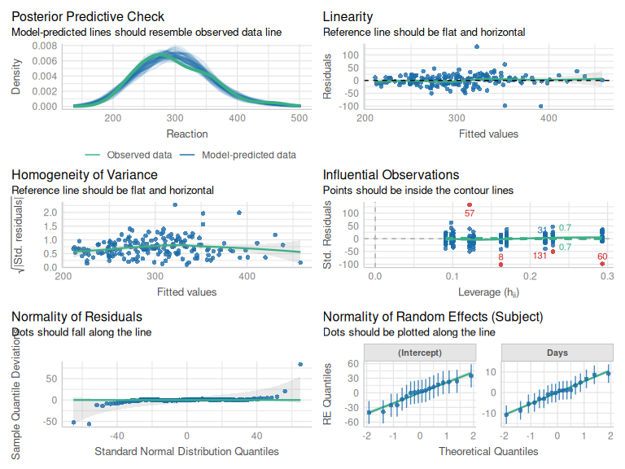

```r
performance::check_model(mod_ss)
```

For those working with mixed models, it may important to check whether some dimensions of the variance-covariance are estimated to be zero.

```r
performance::check_singularity(mod_ss)
```

```
## [1] FALSE
```

## DHARMa

The [DHARMa](https://cran.r-project.org/web/packages/DHARMa/vignettes/DHARMa.html) package uses a simulation-based method for residual checks for generalized linear (mixed) models.

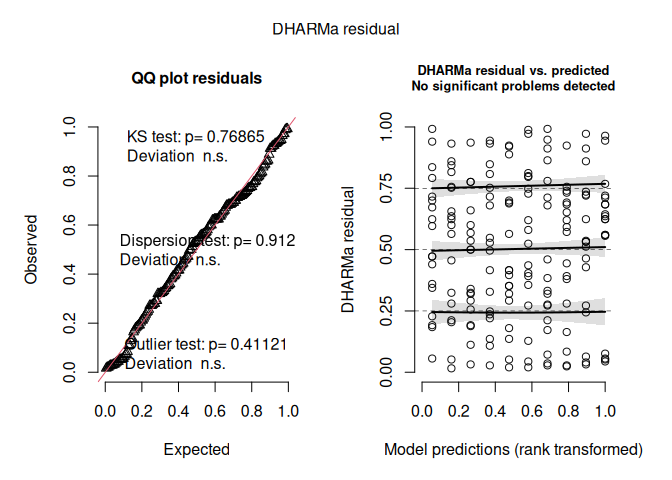

```r
simulationOutput <- DHARMa::simulateResiduals(fittedModel = mod_ss)
plot(simulationOutput)
```

The left plot performs three tests, the Kolmogorov–Smirnov test, simulation-based dispersion tests (see `??DHARMa::testDispersion`), and simulation-based outlier tests (see `??DHARMa::testOutliers`).

## Car

The car package was designed for “An R Companion to Applied Regression” to provide functions that are applied to a fitted regression model. The `car::influencePlot()` creates a diagnostic bubble plot that visualizes influential observations in a regression by plotting Studentized residuals against leverage (hat values), with bubble size representing Cook’s distance.

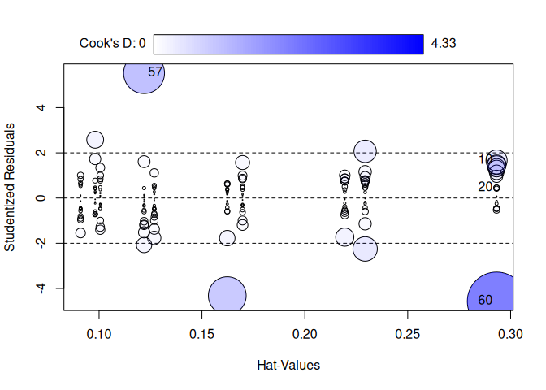

```
##       StudRes       Hat     CookD
## 10  1.6589487 0.2931772 0.5707626
## 20  0.4498749 0.2931772 0.0419733
## 57  5.5270053 0.1218763 2.1198891
## 60 -4.5704359 0.2931772 4.3321637
```

```r
car::influencePlot(mod_ss)
```

# Model Comparison & Performance

Most model comparisons for `merMod` objects will focus on the fixed effects, and the ones shown will be just for fixed effects unless otherwise stated.

## Performance

```r
performance::model_performance(mod_ss)
```

```
## # Indices of model performance
##
## AIC      |     AICc |      BIC | R2 (cond.) | R2 (marg.) |   ICC |   RMSE |  Sigma
## ----------------------------------------------------------------------------------
## 1755.628 | 1756.114 | 1774.786 |      0.799 |      0.279 | 0.722 | 23.438 | 25.592
```

We can also use `performance::compare_performance()`.

```r
performance::compare_performance(mod_ss, mod_ss2)
```

```
## # Comparison of Model Performance Indices
##
## Name    |   Model |  AIC (weights) | AICc (weights) |  BIC (weights) |   RMSE |  Sigma | R2 (cond.)
## ---------------------------------------------------------------------------------------------------
## mod_ss  | lmerMod | 1764.0 (>.999) | 1764.5 (>.999) | 1783.1 (>.999) | 23.438 | 25.592 |      0.799
## mod_ss2 |      lm | 1906.3 (<.001) | 1906.4 (<.001) | 1915.9 (<.001) | 47.449 | 47.715 |
##
## Name    | R2 (marg.) |   ICC |    R2 | R2 (adj.)
## ------------------------------------------------
## mod_ss  |      0.279 | 0.722 |       |
## mod_ss2 |            |       | 0.286 |     0.282
```

## Pbkrtest

The [pbkrtest](https://hojsgaard.github.io/pbkrtest/index.html) package implements three tests to examine fixed effects from linear mixed-effects models (LMM): - Parametric bootstrap test `pbkrtest::PBmodcomp()` - Kenward-Roger-type F-test `pbkrtest::KRmodcomp()` - Satterthwaite-type F-test `pbkrtest::SATmodcomp()`

```r
fm0 <- lmer(weight ~ Time + (1|Chick), data = ChickWeight)
fm1 <- update(fm0, .~.-Time)

pbkrtest::PBmodcomp(fm0, fm1)
```

```
## Bootstrap test; time: 21.32 sec; samples: 1000; extremes: 0;
## large : weight ~ Time + (1 | Chick)
##          stat df   p.value
## LRT    926.47  1 < 2.2e-16 ***
## PBtest 926.47     0.000999 ***
## ---
## Signif. codes:  0 '***' 0.001 '**' 0.01 '*' 0.05 '.' 0.1 ' ' 1
```

```r
pbkrtest::KRmodcomp(fm0, fm1)
```

```
## large : weight ~ Time + (1 | Chick)
## small : weight ~ (1 | Chick)
##          stat     ndf     ddf F.scaling   p.value
## Ftest 2471.07    1.00  530.53         1 < 2.2e-16 ***
## ---
## Signif. codes:  0 '***' 0.001 '**' 0.01 '*' 0.05 '.' 0.1 ' ' 1
```

```r
pbkrtest::SATmodcomp(fm0, fm1)
```

```
## large : weight ~ Time + (1 | Chick)
## small : weight ~ (1 | Chick)
##      statistic    ndf    ddf   p.value
## [1,]    2471.7    1.0 530.93 < 2.2e-16 ***
## ---
## Signif. codes:  0 '***' 0.001 '**' 0.01 '*' 0.05 '.' 0.1 ' ' 1
```

Note: the `pbkrtest::KRmodcomp()` function was package was intended for `lmerMod` objects only, as the Kenward-Roger-type F-test was designed for fitted linear mixed models.

## MuMIn

The [MuMIn](https://cran.r-universe.dev/MuMIn/doc/manual.html) package provides tools for model selection by automating the process through subsets of the maximum model.

```r
options(na.action = "na.fail")

mumin_compare = MuMIn::dredge(mod_cw)
mumin_compare
```

```
## Global model call: lmer(formula = weight ~ Time + Diet + (1 | Chick), data = ChickWeight,
##     REML = FALSE)
## ---
## Model selection table
##   (Intrc) Diet  Time df    logLik   AICc  delta weight
## 4   11.23    + 8.718  7 -2802.600 5619.4   0.00  0.996
## 3   27.84      8.726  4 -2811.172 5630.4  11.02  0.004
## 2  101.80    +        6 -3265.144 6542.4 923.04  0.000
## 1  121.00             3 -3274.405 6554.9 935.46  0.000
## Models ranked by AICc(x)
## Random terms (all models):
##   1 | Chick
```

`MuMIn::dredge()` doesn’t print the fitted model object, so to find which the labelled models 1, 2, etc., correspond to, use `get.models(mumin_compare, subset = TRUE)`. The output tends to be long and is omitted for space reasons.

## RLRsim

A common way to test the significance of random effects is through a likelihood ratio test. The RLRsim package includes fast simulation-based exact tests that is compatible with `lmerMod` objects.

```r
# First model is one with the random effects,
# the second is must be a lm-object.
RLRsim::exactLRT(m = mod_cw, m0 = mod_cw2)
```

```
## No restrictions on fixed effects. REML-based inference preferable.
```

```
##
##  simulated finite sample distribution of LRT. (p-value based on 10000 simulated values)
##
## data:
## LRT = 172.41, p-value < 2.2e-16
```

## Multcomp

The [multcomp](https://multcomp.r-forge.r-project.org/) package was designed for performing general linear hypotheses in parametric models.

```r
glh_cw = multcomp::glht(mod_cw)
summary(glh_cw)
```

```
##
##   Simultaneous Tests for General Linear Hypotheses
##
## Fit: lmer(formula = weight ~ Time + Diet + (1 | Chick), data = ChickWeight,
##     REML = FALSE)
##
## Linear Hypotheses:
##                  Estimate Std. Error z value Pr(>|z|)
## (Intercept) == 0  11.2311     5.5780   2.013  0.17828
## Time == 0          8.7175     0.1753  49.742  < 0.001 ***
## Diet2 == 0        16.2193     9.0788   1.787  0.28082
## Diet3 == 0        36.5527     9.0788   4.026  < 0.001 ***
## Diet4 == 0        30.0255     9.0855   3.305  0.00447 **
## ---
## Signif. codes:  0 '***' 0.001 '**' 0.01 '*' 0.05 '.' 0.1 ' ' 1
## (Adjusted p values reported -- single-step method)
```

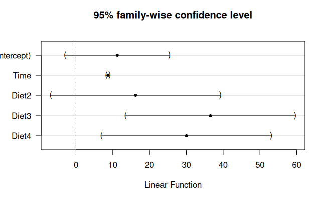

```r
plot(glh_cw)
```

## Car

`car::Anova()` can be used traditional ANOVA-style tables using Wald $\chi^{2}$ statistics on the fixed effects only.

```r
car::Anova(mod_cw)
```

```
## Analysis of Deviance Table (Type II Wald chisquare tests)
##
## Response: weight
##         Chisq Df Pr(>Chisq)
## Time 2474.247  1  < 2.2e-16 ***
## Diet   20.466  3  0.0001359 ***
## ---
## Signif. codes:  0 '***' 0.001 '**' 0.01 '*' 0.05 '.' 0.1 ' ' 1
```

## Insight

As its name suggests, the [insight](https://easystats.github.io/insight/index.html) package was designed to easily gather information from statistical models from a variety of different object types. Their documentation already covers examples of `merMod` objects [here](https://easystats.github.io/insight/articles/insight.html#examples).

# Plotting & Prediction

```r
library(ggplot2)
```

## Dotwhisker

The [dotwhisker](https://fsolt.org/dotwhisker/) package was designed to easily make dot-and-whisker plots from regression results. We recommend scaling by two standard deviations as recommended by [Gelman (2008).](https://doi.org/10.1002/sim.3107).

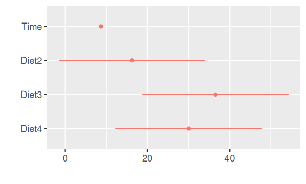

```r
effects_gt <- broom.mixed::tidy(mod_cw, effect = "fixed", conf.int = TRUE)

dotwhisker::dwplot(effects_gt, by_2sd = TRUE)
```

Notice that we combined the usage of broom.mixed package to extract the fixed effects (for the dot-and-whisker plots). Details can be found by clicking the url for broom.mixed or see this section.

## Emmeans

As its name implies, the [emmeans](https://rvlenth.github.io/emmeans/) package obtains the estimated marginal means.

More details and examples for `lmerMod` objects can be found [here.](https://cran.r-project.org/web/packages/emmeans/vignettes/sophisticated.html)

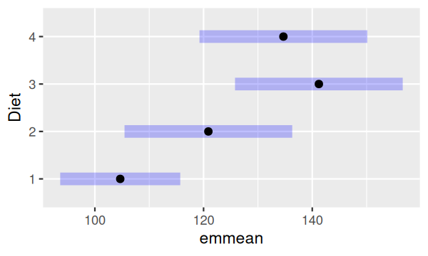

```r
plot(emmeans::emmeans(mod_cw, "Diet"))
```

## SjPlot

The [sjPlot](https://strengejacke.github.io/sjPlot/) package was built for easier plotting and table outputs.

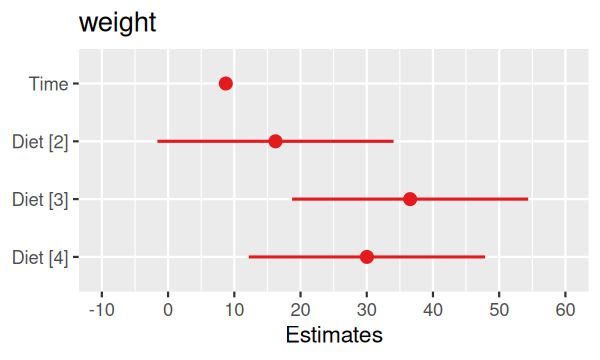

```r
sjPlot::plot_model(mod_cw)
```

## ggEffects

The [ggEffects](https://strengejacke.github.io/ggeffects/) package also computes the marginal effects, returning ready-to-graph results via the [ggplot2](https://ggplot2.tidyverse.org/) package.

The [ggEffects documentation](https://strengejacke.github.io/ggeffects/articles/introduction_randomeffects.html) already includes more details and examples for `lmerMod` objects.

```r
predict_ss <- ggeffects::predict_response(mod_ss, "Days [0:9]")
ggplot(predict_ss, aes(x, predicted)) +
  geom_line() + labs(x = "Days", y = "Predicted Reaction") +
  geom_ribbon(aes(ymin = conf.low, ymax = conf.high), alpha = 0.1)
```

[output not shown]

The ggEffects package is supposed to be superseded by [modelbased](https://easystats.github.io/modelbased/), however, it may run errors when using `lmerMod` objects.

## Marginaleffects

As its package name implies, the goal of [marginaleffects](https://marginaleffects.com/) is to compute the marginal means as well as various other model comparisons for a lot of different classes, `merMod` objects being one of them.

More details and examples for mixed models can be found [here.](https://marginaleffects.com/bonus/lme4.html)

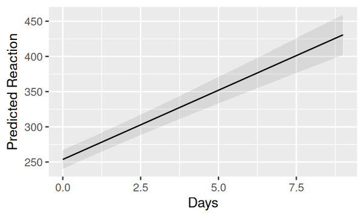

```r
library(marginaleffects)
# Note: datagrid depends on marginaleffects

pred_ss <- predictions(mod_ss, newdata = datagrid(Days = 0:9))
# Plot using ggplot2
ggplot(pred_ss, aes(x = Days, y = estimate)) +
  geom_line() +
  geom_ribbon(aes(ymin = conf.low, ymax = conf.high), alpha = 0.1) +
  labs(x = "Days", y = "Predicted Reaction")
```

# Formatted Regression Tables

Although the output can easily be seen by applying `summary()` to the `merMod` object, it can be useful to use packages that automatically format the results nicely into $\LaTeX$, HTML, and text output. There are many such functions that appear to be compatiable with `merMod` objects.

In this section, we display the code (though it is not executed) along with the resulting HTML output. The corresponding versions for $\LaTeX$ and plain text are equally straightforward.

## SjPlot

The [sjPlot](https://strengejacke.github.io/sjPlot/) package can be used for table outputs in HTML. There is a fantastic example written in their documentation [here.](https://strengejacke.github.io/sjPlot/articles/tab_model_robust.html?q=lme4#robust-covariance-matrix-estimation-for-mixed-models)

## Parameters

The [Parameters](https://easystats.github.io/parameters/index.html) package, as its name suggests, extracts parameters from a fitted model. Their own documentation also includes examples of mixed models from lme4 [here.](https://easystats.github.io/parameters/index.html) and exact table formatting can be found [here.](https://easystats.github.io/parameters/articles/model_parameters_formatting.html)

## Huxtable

The [Huxtable](https://hughjonesd.github.io/huxtable/) package can be used to create $\LaTeX$ (see `huxtable::print_latex()`) and HTML (see `huxtable::print_html()`) output.

```r
h_tab = huxtable::huxreg(mod_ss)
huxtable::print_html(h_tab)
```

|  | (1) |
| --- | --- |
| (Intercept) | 251.405 |
|  | (6.825) |
| Days | 10.467 |
|  | (1.546) |
| sd__(Intercept) | 24.741 |
|  | (NA) |
| cor__(Intercept).Days | 0.066 |
|  | (NA) |
| sd__Days | 5.922 |
|  | (NA) |
| sd__Observation | 25.592 |
|  | (NA) |
| N | 180 |
| logLik | -871.814 |
| AIC | 1755.628 |
| *** p < 0.001; ** p < 0.01; * p < 0.05. |  |

## Stargazer

[Stargazer](https://cran.r-project.org/web/packages/stargazer/index.html) was intended to create well formatted regression tables in $\LaTeX$, HTML/CSS, and plain text.

```r
stargazer::stargazer(mod_ss, type = "html") # use type = "latex" for LaTeX
```

|  | *Dependent variable:* |
| --- | --- |
|  | Reaction |
| Days | 10.467*** |
|  | (1.546) |
| Constant | 251.405*** |
|  | (6.825) |
| Observations | 180 |
| Log Likelihood | -871.814 |
| Akaike Inf. Crit. | 1,755.628 |
| Bayesian Inf. Crit. | 1,774.786 |
| *Note:* | p<0.1; p<0.05; p<0.01 |

## Texreg

We could also use the texreg package to create $\LaTeX$ `texreg::texreg()` and HTML `texreg::htmlreg()` tables.

```r
texreg::htmlreg(mod_ss)
```

Statistical models

|  | Model 1 |
| --- | --- |
| (Intercept) | 251.41*** |
|  | (6.82) |
| Days | 10.47*** |
|  | (1.55) |
| AIC | 1755.63 |
| BIC | 1774.79 |
| Log Likelihood | -871.81 |
| Num. obs. | 180 |
| Num. groups: Subject | 18 |
| Var: Subject (Intercept) | 612.10 |
| Var: Subject Days | 35.07 |
| Cov: Subject (Intercept) Days | 9.60 |
| Var: Residual | 654.94 |

***p < 0.001; **p < 0.01; *p < 0.05

## Memisc

The goal of the [memisc](https://melff.github.io/memisc/) package is to make it easier to deal with survey data sets, such as table formatting in $\LaTeX$ (using `memisc::mtable_format_latex()`) and HTML (using `memisc::mtable_format_html()`).

```r
mem_tab <- memisc::mtable("Model 1"=mod_cw,"Model 2"=mod_cw2,
                          "Model 3"=mod_cw3, summary.stats=c("sigma","R-squared","F","p","N"))

memisc::mtable_format_html(mem_tab)
```

|  | Model 1 |  |  | Model 2 |  |  | Model 3 |  |  |
| --- | --- | --- | --- | --- | --- | --- | --- | --- | --- |
| (Intercept) | 11 | . | 244 | 10 | . | 924** | 27 | . | 845*** |
|  | (5 | . | 789) | (3 | . | 361) | (4 | . | 388) |
| Time | 8 | . | 717*** | 8 | . | 750*** | 8 | . | 726*** |
|  | (0 | . | 175) | (0 | . | 222) | (0 | . | 176) |
| Diet: 2/1 | 16 | . | 210 | 16 | . | 166*** |  |  |  |
|  | (9 | . | 464) | (4 | . | 086) |  |  |  |
| Diet: 3/1 | 36 | . | 543*** | 36 | . | 499*** |  |  |  |
|  | (9 | . | 464) | (4 | . | 086) |  |  |  |
| Diet: 4/1 | 30 | . | 013** | 30 | . | 233*** |  |  |  |
|  | (9 | . | 471) | (4 | . | 107) |  |  |  |
| N | 578 |  |  | 578 |  |  | 578 |  |  |
| R-squared |  |  |  | 0 | . | 745 |  |  |  |
| sigma |  |  |  | 35 | . | 993 |  |  |  |
| F |  |  |  | 419 | . | 177 |  |  |  |
| p |  |  |  | 0 | . | 000 |  |  |  |
| Significance: *** = p < 0.001; ** = p < 0.01; * = p < 0.05 |  |  |  |  |  |  |  |  |  |

# Other

This section covers other external packages that may be useful but does not fall under the category of previous sections.

## Broom.mixed

The [broom](https://broom.tidymodels.org/) package takes output from built-in functions in R and converts them into a [tibble](https://tibble.tidyverse.org/), which is an alternative to R’s built in `data.frame`.

[Broom.mixed](https://cran.r-project.org/web/packages/broom.mixed/index.html) is a spin-off of broom where it takes outputs from outputs from specifically mixed models from various popular mixed model packages, and of course `lme4` is one of them.

```r
broom.mixed::tidy(mod_ss)
```

```
## # A tibble: 6 × 6
##   effect   group    term                  estimate std.error statistic
##   <chr>    <chr>    <chr>                    <dbl>     <dbl>     <dbl>
## 1 fixed    <NA>     (Intercept)           251.          6.82     36.8
## 2 fixed    <NA>     Days                   10.5         1.55      6.77
## 3 ran_pars Subject  sd__(Intercept)        24.7        NA        NA
## 4 ran_pars Subject  cor__(Intercept).Days   0.0656     NA        NA
## 5 ran_pars Subject  sd__Days                5.92       NA        NA
## 6 ran_pars Residual sd__Observation        25.6        NA        NA
```

## Equatiomatic

The [equatiomatic](https://datalorax.github.io/equatiomatic/) package takes a fitted model and writes the equation for you, formatted in $\LaTeX$.

```r
equatiomatic::extract_eq(mod_ss)
```

The output provides $\LaTeX$ code that outputs the following equation:
$$\begin{aligned}
\operatorname{Reaction}_{i} &\sim N \left(\alpha_{j[i]} +
\beta_{1j[i]}(\operatorname{Days}), \sigma^2 \right) \\
\left(
\begin{array}{c}
\begin{aligned}
&\alpha_{j} \\
&\beta_{1j}
\end{aligned}
\end{array}
\right)
&\sim N \left(
\left(
\begin{array}{c}
\begin{aligned}
&\mu_{\alpha_{j}} \\
&\mu_{\beta_{1j}}
\end{aligned}
\end{array}
\right)
,
\left(
\begin{array}{cc}
\sigma^2_{\alpha_{j}} & \rho_{\alpha_{j}\beta_{1j}} \\
\rho_{\beta_{1j}\alpha_{j}} & \sigma^2_{\beta_{1j}}
\end{array}
\right)
\right)
\text{, for Subject j = 1,} \dots \text{,J}
\end{aligned}$$